# Data Feminism

POLS 2140: Introduction to Political Analysis

Dr. Sarah Dreier

## Reading Prompt

*Data Feminism* (D’Ignazio & Klein, 2020), Ch. 1:

Define/describe one of the following terms and explain why it matters for data-based analysis:

- Matrix of Domination
- Privilege Hazard

## Announcements

- **Office Hours Today**: 3:00-4:30 pm (SSCO 2048)
- **Data News Thursday**:
  - Dylan Provencio, Mana Ahmadi, Nathan Saavedra, Maryam Gauba, Jendrik Diaz
  - Also: Reading response from DF Ch 6
- **Refresh your syllabus** after Thurs (reading shift for next week)
- Confusion about *independent* and *dependent variables*: We will go over this more starting next week!

## Do the numbers speak for themselves?

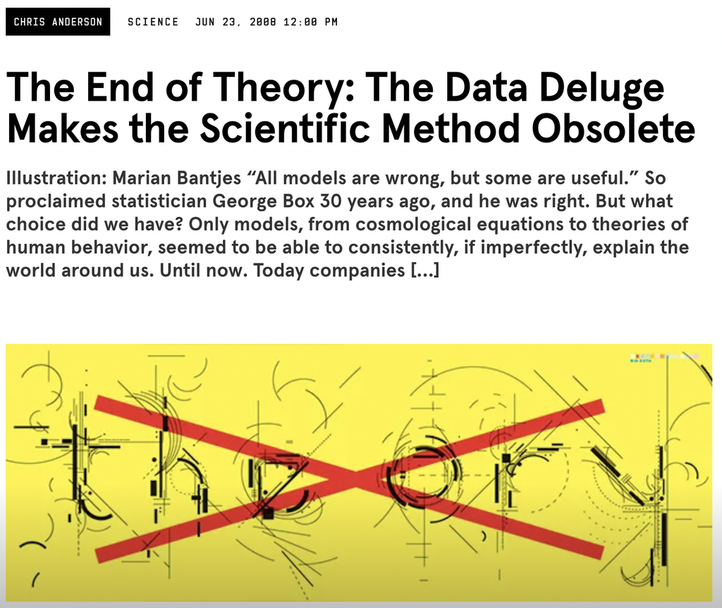

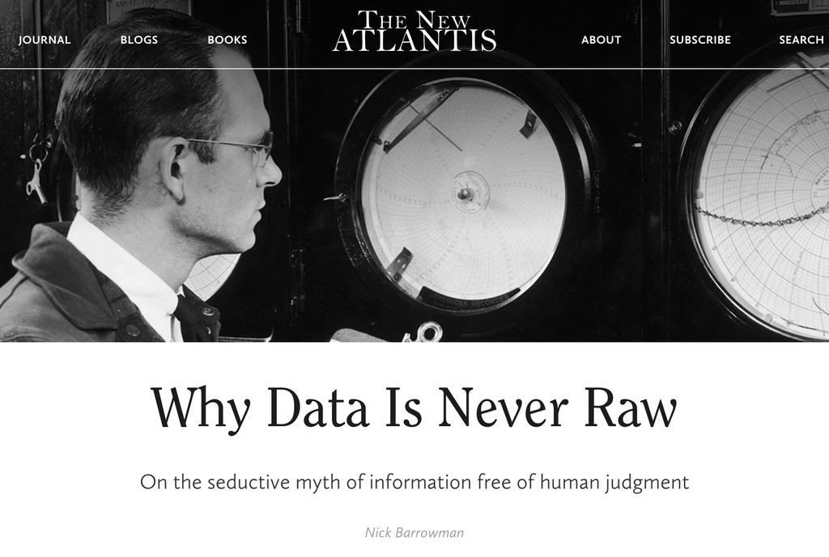

All analyses involve (subjective) human judgments.

## Recall: The production of data is intertwined with **human judgment.**

- All data is **cooked** (and hopefully *cooked with care*)

> “The *context* of data — **why** it was collected, **how** it was collected, and **how** it was transformed [and **how** it is analyzed] — is always relevant. There is, then, no such thing as context-free data, and thus data cannot manifest the kind of perfect objectivity that is sometimes imagined” (Barrowman).
- Statistical analysis requires (hopefully reasonable) human decisions ([Race + Red Cards](https://doi.org/10.1177/2515245917747646))
  - Features we take into consideration (covariates / control variables)
  - Statistical models we employ

Is it necessarily **bad** that our data/analyses are shaped by **human judgement** and the **subjective contexts** in which they are generated?

- Not necessarily bad, but inevitable.

## [Data Feminism](https://data-feminism.mitpress.mit.edu/)

Does this human judgment reflect / influence all of us equally?

- No! Data is subjective — and can reinforce power inequities

**Data feminism:** Power is not distributed equally in the world, and this influences how our data is generated and used.

- Standard practices in data science (and *political science*) can **reinforce** (or **challenge!!**) existing power differentials.

[figure not shown]

## [Data Feminism](https://data-feminism.mitpress.mit.edu/)

**Discussion**:

- What is one thing from the reading you **learned** or one thing that **suprised** you?
- What is one way that the reading prompted you to **think differently** about the data you encounter in your own life?

[figure not shown]

## What is *POWER*?

- **Power:** “the current configuration of structural privilege and structural oppression, in which some groups experience unearned advantages… and other groups experience systematic disadvantages.”
- **Minoritized groups:** People who are actively devalued and oppressed by a more powerful social group (dominant group) that has more access to economic, social, and political resources.
- **Matrix of domination** (dimensions of **power**) (Collins 1990):
  - *Structural domain:* Laws, policies, mechanisms of enforcement that directly target minoritized groups
  - *Disciplinary domain:* Rules or procedures that (perhaps indirectly) manage or discipline minoritized groups
  - *Hegemonic domain:* Social norms — culture, media, ideas — that send oppressive messages about a minoritized group
  - *Interpersonal domain:* Everyday oppressive experiences of minoritized individuals

## Matrix of Domination

How might power operate in each domain for an **undocumented parent**?

**Structural domain**

[figure not shown]

**Disciplinary domain**

[figure not shown]

**Hegemonic domain**

[figure not shown]

**Interpersonal domain**

[figure not shown]

## Missing perspectives, missing data

What is the **privilege hazard**?

- “The phenomenon that makes those who occupy the most privileged positions among us…so poorly equipped to recognize instances of oppression in the world (Data Feminism, p. 29)
- What are some risks associated with this **privilege hazard**?

Among other issues: **missing datasets**

- Examples from reading or your own observations?
- Other ways to think about **missing data**”:
  - Who gets to tell their own story and self-dictate the data associated with themselves?
  - Who has their story told for them or their data dictated for them?
  - Ex: Women in the developing world asked about their contraception, not the sports they play.

## What is *POWER*? (Adichie 2009)

Clip: 0:10 – 3:00; 8:30 – 12:00

## The danger of a single story

- What data was missing in Adichie’s life?
- How could we run the risk of “the danger of a single story” when approaching social science research and/or data analysis? What harm(s) could this do?
- What are steps to reduce, mitigate, or reverse these dangers?

## TL;DR

- **Data is never neutral.** Every dataset is the product of human judgment and the unequal social conditions it was collected under (D’Ignazio & Klein, 2020).
- **Human decisions run through the whole pipeline** — the questions we ask, how we produce data, and how we analyze it (which covariates, which models: *Race + Red Cards*).
- **Data feminism** starts from the premise that power is not distributed equally, and that standard data-science practice can reinforce — or challenge — those inequities.
- **The matrix of domination** (structural, disciplinary, hegemonic, interpersonal) is a tool for seeing how power operates across those domains.
- **The privilege hazard** leaves those in the most privileged positions least equipped to notice oppression — producing *missing data* and *missing datasets*.
- **The danger of a single story:** who gets to tell their own story, and who has it told for them, shapes what the data can say.

## References

D’Ignazio, C., & Klein, L. F. (2020). *Data feminism*. MIT Press. https://data-feminism.mitpress.mit.edu/